# svc_norm_2factor.r

jflournoy

Thu Aug 13 18:36:15 2015

# Descriptives

These histograms by themselves tell a really interesting story – you can see that there is a some overlap between Acc and Cont ratings, but some items distinguish between them. These line up with a lot of our *a priori* ideas – see anger and jealousy. Pretty cool.

Aside from the status items, you also can see the scores on depression and substance use, among other things. Keep in mind the middle 2 CES_D items are reverse coded. SES ladder is mostly between 3-7 on a 9 point scale.

[figure not shown]

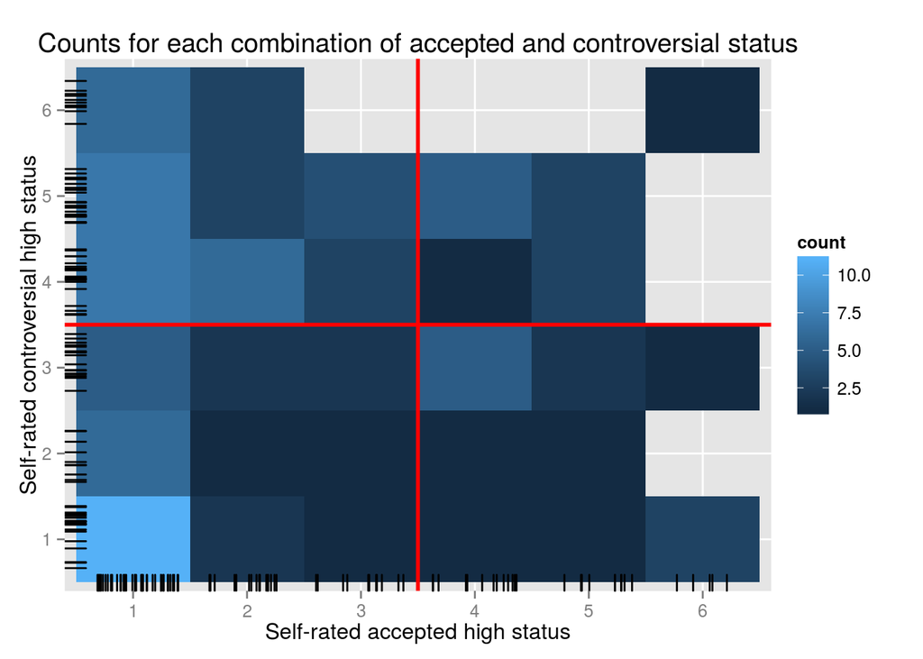

Controversial versus Accepted Status Frequencies

| Cont_v_Acc | 1 | 2 | 3 | 4 | 5 | 6 |
| --- | --- | --- | --- | --- | --- | --- |
| 1 | 11 | 6 | 5 | 7 | 7 | 6 |
| 2 | 2 | 1 | 2 | 6 | 3 | 3 |
| 3 | 1 | 1 | 2 | 3 | 4 | 0 |
| 4 | 1 | 1 | 5 | 1 | 5 | 0 |
| 5 | 1 | 1 | 2 | 3 | 3 | 0 |
| 6 | 3 | 0 | 1 | 0 | 0 | 1 |

# Self Ratings

## Best predictors of status

First thing, let’s see what items are best at predicting status using regularized regression for multinomial responses. This uses cross validation to give us the set of predictors that leads to the best out-of-sample prediction (least error). We probably want these in our set of final items.

The first plot shows how prediction error varies as a function of the number of parameters in the model, and how much weight each gets (the size of the coefficient).

The second set of plots actually show the size of each coefficient predicting both types of status as the constraint parameter, lambda, is tightened (left-to-right).

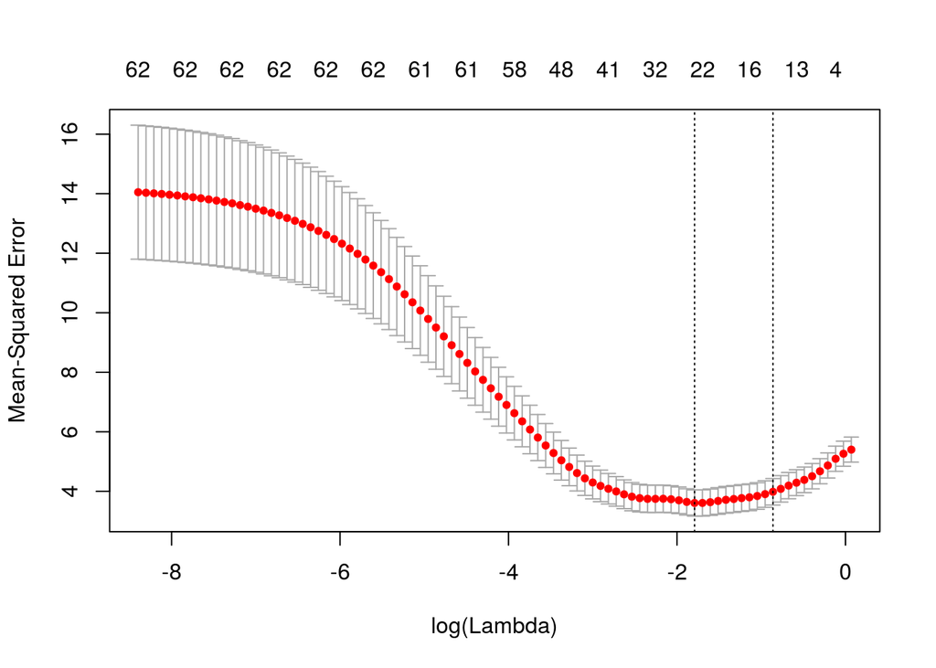

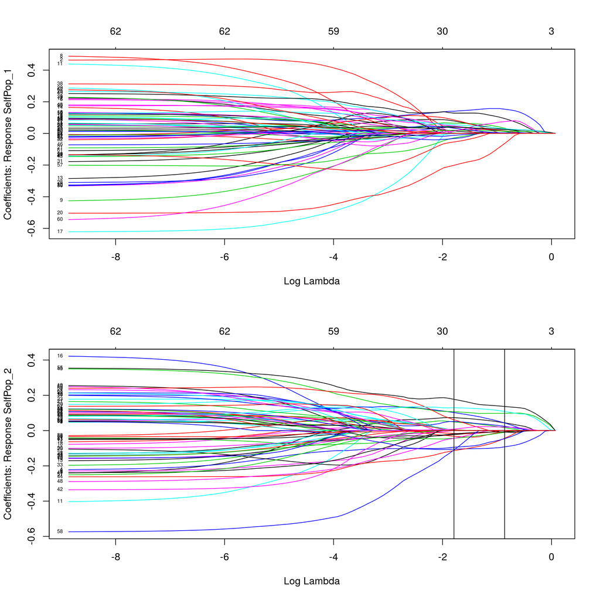

This table shows all the non-zero coefficients.

Best predictors of self-report status

| xName | ContStat | AccStat |
| --- | --- | --- |
| (Intercept) | 1.424 | 2.787 |
| admired_Self | 0.079 | 0.074 |
| agressive_Self | 0.065 | 0.049 |
| angry_Self | 0.140 | -0.105 |
| awkward_Self | 0.016 | -0.023 |
| cool_Self | 0.047 | 0.052 |
| grumpy_Self | 0.043 | -0.043 |
| jealous_Self | 0.086 | -0.016 |
| leader_Self | -0.012 | 0.102 |
| mean_Self | 0.035 | 0.005 |
| poor_Self | 0.019 | -0.113 |
| popular_Self | 0.020 | 0.107 |
| risky_Self | 0.047 | -0.044 |
| rude_Self | 0.128 | -0.019 |
| rulefollower_Self | -0.054 | 0.061 |
| selfish_Self | 0.003 | -0.001 |
| shy_Self | 0.033 | -0.094 |
| snobby_Self | 0.014 | 0.008 |
| social_Self | 0.040 | 0.177 |
| studious_Self | -0.029 | 0.002 |
| trendy_Self | 0.055 | 0.130 |

If we were merely trying to predict status from a future data set containing these same items, the above table would be the best subset to use.

While we’re interested in predicting status, we’re not actually asking about status. Rather, we’re asking about traits that we think relate to status. So while the above set of items might tell us who is likely to have one or the other kind of status, in the context of an fMRI analysis it would be hard to argue that activity observed during self evaluation of these traits is some measure of status-related brain activity.

## EFA to look at latent constructs

The more traditional approach would be to use EFA. What we hope to get is 2 factors the correspond to Accepted High Status and Controversial High Status.

However, the scree plot shows *very* clearly a 4 factor solution will account for most of the variance, with no real gain if we increase beyond 4. Ignoring that, we want the best 2 factor solution so that we can run reasonable contrasts between these two sets. We can think of them as super-factors, perhaps.

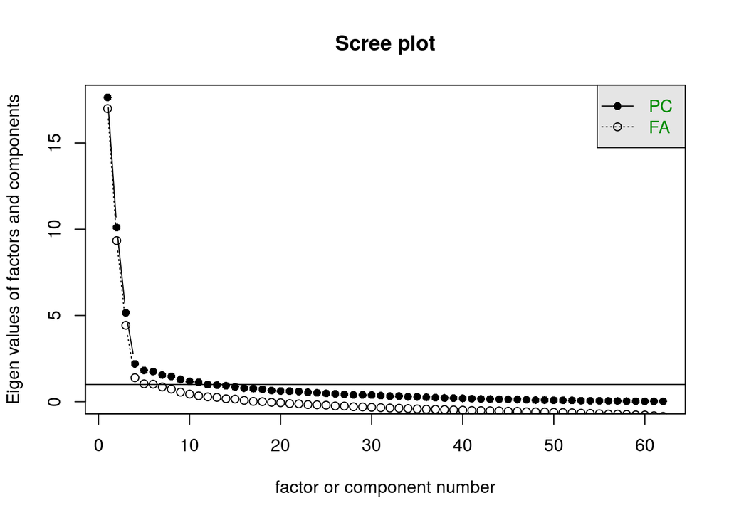

Here’s the raw output, if you like, but see below for a prettier table. Notice the factors are allowed to (anti) correlate.

```
## Factor Analysis using method =  pa
## Call: fa(r = select(selfRateDat, -matches("SelfPop")), nfactors = 2,
##     rotate = "oblimin", scores = "tenBerge", fm = "pa", use = "pairwise.complete.obs")
## Standardized loadings (pattern matrix) based upon correlation matrix
##                    item   PA1   PA2    h2   u2 com
## popular_Self         45  0.85  0.02 0.730 0.27 1.0
## social_Self          55  0.84  0.01 0.714 0.29 1.0
## confident_Self       13  0.84  0.09 0.740 0.26 1.0
## trendy_Self          59  0.83 -0.10 0.674 0.33 1.0
## cool_Self            16  0.81 -0.07 0.641 0.36 1.0
## admired_Self          1  0.80 -0.05 0.635 0.37 1.0
## attractive_Self       6  0.76  0.12 0.620 0.38 1.1
## outgoing_Self        41  0.73 -0.04 0.520 0.48 1.0
## flirty_Self          22  0.72 -0.14 0.511 0.49 1.1
## loner_Self           36 -0.71 -0.15 0.567 0.43 1.1
## leader_Self          34  0.70 -0.12 0.482 0.52 1.1
## insecure_Self        31 -0.69 -0.14 0.537 0.46 1.1
## adventurous_Self      2  0.69  0.01 0.472 0.53 1.0
## shy_Self             52 -0.63  0.13 0.383 0.62 1.1
## lonely_Self          35 -0.62 -0.17 0.452 0.55 1.1
## depressed_Self       19 -0.62 -0.21 0.467 0.53 1.2
## funny_Self           24  0.61  0.15 0.420 0.58 1.1
## daring_Self          17  0.58 -0.20 0.342 0.66 1.2
## awkward_Self          7 -0.57 -0.13 0.371 0.63 1.1
## plain_Self           43 -0.56 -0.04 0.329 0.67 1.0
## ugly_Self            61 -0.53 -0.31 0.439 0.56 1.6
## boring _Self          8 -0.51 -0.25 0.366 0.63 1.4
## comforting_Self      12  0.44  0.36 0.383 0.62 1.9
## pushover_Self        46 -0.43 -0.17 0.238 0.76 1.3
## athletic_Self         5  0.39  0.09 0.169 0.83 1.1
## mean_Self            38  0.20 -0.79 0.607 0.39 1.1
## snobby_Self          54  0.23 -0.78 0.608 0.39 1.2
## rude_Self            49  0.25 -0.74 0.547 0.45 1.2
## nice_Self            40  0.15  0.73 0.587 0.41 1.1
## considerate_Self     14  0.05  0.71 0.525 0.48 1.0
## fake_Self            21 -0.05 -0.70 0.500 0.50 1.0
## agressive_Self        3  0.31 -0.69 0.503 0.50 1.4
## selfish_Self         51  0.07 -0.69 0.461 0.54 1.0
## welcoming_Self       62  0.24  0.65 0.538 0.46 1.3
## bossy_Self            9  0.47 -0.65 0.535 0.47 1.8
```

[output cut: 46 more lines]

```
## The root mean square of the residuals (RMSR) is  0.1
## The df corrected root mean square of the residuals is  0.1
##
## The harmonic number of observations is  99 with the empirical chi square  3502.54  with prob <  8.8e-117
## The total number of observations was  100  with MLE Chi Square =  3147.64  with prob <  1.2e-80
##
## Tucker Lewis Index of factoring reliability =  0.59
## RMSEA index =  0.115  and the 90 % confidence intervals are  0.083 NA
## BIC =  -4994.3
## Fit based upon off diagonal values = 0.91
## Measures of factor score adequacy
##                                                 PA1  PA2
## Correlation of scores with factors             0.99 0.98
## Multiple R square of scores with factors       0.97 0.96
## Minimum correlation of possible factor scores  0.95 0.93
```

These factors are pretty interpretable, if you ask me.

1. First (PA1), is surgency/dynamism/extraversion: Popular; not depressed, lonely, or insecure; trendy, confident, popular, social. Daring and adventurous.
2. Third (PA2), we have…aggression (reversed, ’cause EFA)? Rude, mean, bossy, snobby, as well as lazy and fake, not sympathetic, not trustworthy.

Here’s nice table:

| item | PA1 | PA2 | comm |
| --- | --- | --- | --- |
| popular_Self | 0.85 |  | 0.730 |
| social_Self | 0.84 |  | 0.714 |
| confident_Self | 0.84 |  | 0.740 |
| trendy_Self | 0.83 | -0.10 | 0.674 |
| cool_Self | 0.81 |  | 0.641 |
| admired_Self | 0.80 |  | 0.635 |
| attractive_Self | 0.76 | 0.12 | 0.620 |
| outgoing_Self | 0.73 |  | 0.520 |
| flirty_Self | 0.72 | -0.14 | 0.511 |
| loner_Self | -0.71 | -0.15 | 0.567 |
| leader_Self | 0.70 | -0.12 | 0.482 |
| insecure_Self | -0.69 | -0.14 | 0.537 |
| adventurous_Self | 0.69 |  | 0.472 |
| shy_Self | -0.63 | 0.13 | 0.383 |
| lonely_Self | -0.62 | -0.17 | 0.452 |
| depressed_Self | -0.62 | -0.21 | 0.467 |
| funny_Self | 0.61 | 0.15 | 0.420 |
| daring_Self | 0.58 | -0.20 | 0.342 |
| awkward_Self | -0.57 | -0.13 | 0.371 |
| plain_Self | -0.56 |  | 0.329 |
| ugly_Self | -0.53 | -0.31 | 0.439 |
| boring _Self | -0.51 | -0.25 | 0.366 |
| comforting_Self | 0.44 | 0.36 | 0.383 |
| pushover_Self | -0.43 | -0.17 | 0.238 |
| athletic_Self | 0.39 |  | 0.169 |
| mean_Self | 0.20 | -0.79 | 0.607 |
| snobby_Self | 0.23 | -0.78 | 0.608 |
| rude_Self | 0.25 | -0.74 | 0.547 |
| nice_Self | 0.15 | 0.73 | 0.587 |
| considerate_Self |  | 0.71 | 0.525 |
| fake_Self |  | -0.70 | 0.500 |
| agressive_Self | 0.31 | -0.69 | 0.503 |
| selfish_Self |  | -0.69 | 0.461 |
| welcoming_Self | 0.24 | 0.65 | 0.538 |
| bossy_Self | 0.47 | -0.65 | 0.535 |
| angry_Self |  | -0.64 | 0.416 |
| fair_Self | 0.14 | 0.62 | 0.433 |
| genuine_Self | 0.18 | 0.61 | 0.441 |
| caring_Self | 0.24 | 0.60 | 0.470 |
| helpful_Self | 0.31 | 0.60 | 0.512 |
| sympathetic_Self | 0.18 | 0.59 | 0.420 |
| trustworthy_Self | 0.29 | 0.59 | 0.492 |
| friendly_Self | 0.32 | 0.58 | 0.498 |
| humble_Self | -0.16 | 0.58 | 0.327 |
| grumpy_Self | -0.14 | -0.57 | 0.376 |
| loyal_Self |  | 0.57 | 0.350 |
| calm_Self | 0.24 | 0.56 | 0.421 |
| patient_Self | 0.14 | 0.56 | 0.361 |
| controlling_Self | 0.51 | -0.56 | 0.475 |
| giving_Self | 0.25 | 0.53 | 0.389 |
| lazy_Self |  | -0.52 | 0.266 |
| honest_Self | 0.28 | 0.51 | 0.387 |
| respectful_Self | 0.14 | 0.49 | 0.288 |
| poor_Self | -0.36 | -0.46 | 0.405 |
| jealous_Self | -0.14 | -0.44 | 0.236 |
| smart_Self | 0.13 | 0.41 | 0.202 |
| studious_Self |  | 0.40 | 0.162 |
| motivated_Self | 0.27 | 0.39 | 0.263 |
| rule-follower_Self |  | 0.39 | 0.150 |
| risky_Self | 0.38 | -0.38 | 0.242 |
| stubborn_Self | 0.17 | -0.28 | 0.088 |
| dependent_Self |  | -0.18 | 0.039 |

I think this plot is supposed to show how much separation we get – not bad actually.

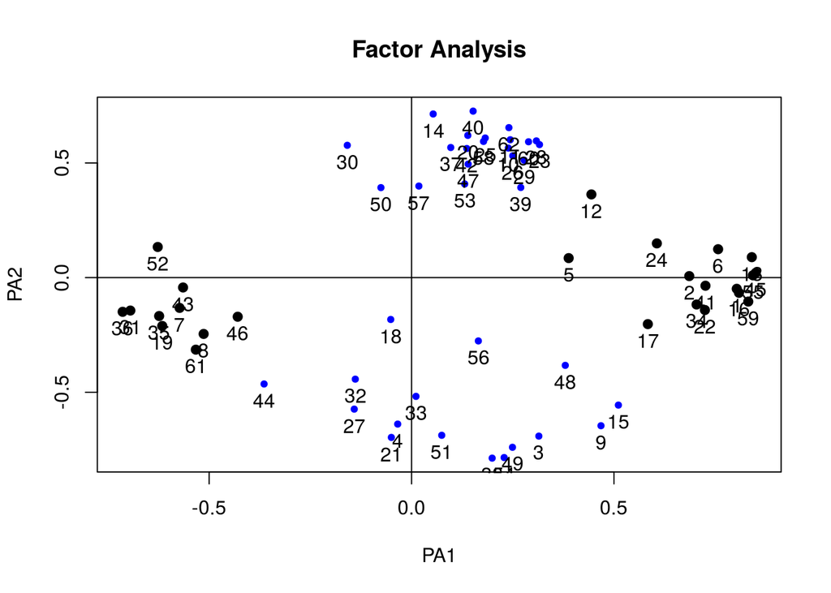

These clusters of items may still be related to status (and they’re actually pretty close to the expected factors). We can correlate self rated accepted and controversial status with the factor scores to start exploring this.

### Correlations

In the output below, SelfPop_1 is controversial, and SelfPop_2 is accepted.

Also:

1. ‘Admired’ (PA1; named after its first item)
2. ‘Aggressive’ (PA2)

We see that controversial status is correlated with ‘Aggressive’.

Accepted status is highly correlated with ‘Admired’.

```
## Call:corr.test(x = as.data.frame(selfPopDat), y = as.data.frame(predict(selfRateFA,
##     selfRateDat_nopop_imputed, missing = T, use = "pairwise.complete.obs")),
##     use = "pairwise.complete.obs", adjust = "none")
## Correlation matrix
##             V1    V2
## SelfPop_1 0.17 -0.53
## SelfPop_2 0.69  0.08
## Sample Size
##            V1  V2
## SelfPop_1  98  98
## SelfPop_2 100 100
##             V1   V2
## SelfPop_1 0.09 0.00
## SelfPop_2 0.00 0.45
##
##  To see confidence intervals of the correlations, print with the short=FALSE option
```

Grain of salt: No correction for multiple comparison here.

Slightly bigger grain of salt: 8 folks are missing a rating on a couple items here and there, so I impute the mean so we can get predicted factor scores. This means that significance values and CIs close to threshold below should be treated lightly (but it doesn’t change things too much).

This gets more interesting in the regressions.

### Regressing Controversial Status

Here’s the raw output for regressing controversial status on the component scores – see below for a table with CIs.

```
##
## Call: rlm(formula = selfPopDat[, c("SelfPop_1")] ~ predict(selfRateFA,
##     selfRateDat_nopop_imputed))
## Residuals:
##      Min       1Q   Median       3Q      Max
## -2.90890 -0.76959 -0.09213  0.71019  3.72106
##
## Coefficients:
##                                                 Value   Std. Error t value
## (Intercept)                                      2.3405  0.1271    18.4201
## predict(selfRateFA, selfRateDat_nopop_imputed)1  0.2414  0.1280     1.8856
## predict(selfRateFA, selfRateDat_nopop_imputed)2 -0.9463  0.1282    -7.3795
##
## Residual standard error: 1.121 on 95 degrees of freedom
##   (2 observations deleted due to missingness)
```

Results from bootstrap estimates: Controversial status is significantly predicted by higher ‘Admired’ scores (1), and higher ‘Aggression’ scores (2; remember the sign reversal).

Controversial status relation with component scores, bootstrapped CIs

| component | est | lower 95% | upper 95% |
| --- | --- | --- | --- |
| 1 | 0.24 | 0.06 | 0.47 |
| 2 | -0.95 | -1.22 | -0.65 |

### Regressing Accepted Status

Here’s the raw output for an rlm of accepted status on the component scores. Again, scroll down for a nice table.

```
##
## Call: rlm(formula = selfPopDat[, c("SelfPop_2")] ~ predict(selfRateFA,
##     selfRateDat_nopop_imputed))
## Residuals:
##      Min       1Q   Median       3Q      Max
## -3.73380 -0.67569  0.07838  0.59266  1.96190
##
## Coefficients:
##                                                 Value   Std. Error t value
## (Intercept)                                      3.5944  0.1215    29.5737
## predict(selfRateFA, selfRateDat_nopop_imputed)1  1.2285  0.1222    10.0512
## predict(selfRateFA, selfRateDat_nopop_imputed)2  0.0670  0.1223     0.5473
##
## Residual standard error: 0.9464 on 97 degrees of freedom
```

Accepted status is significantly predicted by higher ‘Admired’ scores, but not by ‘Aggressive’ scores.

Accepted status relation with component scores, bootstrapped CIs

| component | est | lower 95% | upper 95% |
| --- | --- | --- | --- |
| 1 | 1.23 | 1.02 | 1.42 |
| 2 | 0.07 | -0.12 | 0.28 |

### What has EFA told us?

Well, we have four factors that we’ve forced into 2 that are helpfully related to self reported status. This is what we want.

## EFA using machine learning to select items

Now we need a principled way to select items. We could use some communality cutoff, or loading strength. But we know we want 48 items, so let’s start there. We can use regularized regression methods to let the machine learn what 48 items (or 50 so we can drop a couple if they’re a little out of balance) give us the best set of factors. We can then compare that to the EFA results as well as to the earlier classification.

[output not shown]

```
## [[1]]
##   para Nitems
##   0.96  50.00
##
## [[2]]
##   para Nitems
##   0.97  50.00
##
## [[3]]
##   para Nitems
##   0.98  49.00
##
## [[4]]
##   para Nitems
##   0.99  49.00
##
## [[5]]
##   para Nitems
##      1     49
##
## [[6]]
##   para Nitems
##   1.01  49.00
##
## [[7]]
##   para Nitems
##   1.02  47.00
```

A penalty parameter of .97 (#2) gives us the number of items we want (50 unique, leaving 2 to drop).

|  | PC1 | PC2 |
| --- | --- | --- |
| admired_Self | -0.177 |  |
| adventurous_Self | -0.213 |  |
| agressive_Self |  | 0.164 |
| angry_Self |  | 0.275 |
| athletic_Self | -0.005 |  |
| attractive_Self | -0.253 |  |
| awkward_Self | 0.152 |  |
| boring _Self | 0.01 |  |
| bossy_Self |  | 0.376 |
| calm_Self |  |  |
| caring_Self |  |  |
| comforting_Self | -0.073 | -0.072 |
| confident_Self | -0.295 |  |
| considerate_Self |  | -0.001 |
| controlling_Self |  | 0.011 |
| cool_Self | -0.226 |  |
| daring_Self |  |  |
| dependent_Self |  |  |
| depressed_Self | 0.136 |  |
| fair_Self |  | -0.188 |
| fake_Self |  | 0.228 |
| flirty_Self | -0.118 |  |
| friendly_Self |  | -0.045 |
| funny_Self | -0.136 |  |
| genuine_Self |  | -0.128 |
| giving_Self |  | -0.033 |
| grumpy_Self |  | 0.139 |
| helpful_Self |  |  |
| honest_Self |  | -0.076 |
| humble_Self |  | -0.026 |
| insecure_Self | 0.287 |  |
| jealous_Self |  | 0.094 |
| lazy_Self |  | 0.168 |
| leader_Self | -0.201 |  |
| lonely_Self | 0.198 |  |
| loner_Self | 0.245 |  |
| loyal_Self |  |  |
| mean_Self |  | 0.383 |
| motivated_Self |  |  |
| nice_Self |  |  |
| outgoing_Self | -0.092 |  |
| patient_Self |  | -0.232 |
| plain_Self | 0.076 |  |
| poor_Self | 0.035 | 0.162 |
| popular_Self | -0.376 |  |
| pushover_Self | 0.004 |  |
| respectful_Self |  |  |
| risky_Self |  | 0.1 |
| rude_Self |  | 0.037 |
| rule-follower_Self |  | -0.031 |
| selfish_Self |  | 0.16 |
| shy_Self | 0.1 |  |
| smart_Self |  |  |
| snobby_Self |  | 0.545 |
| social_Self | -0.43 |  |
| stubborn_Self |  |  |
| studious_Self |  | -0.051 |
| sympathetic_Self |  | -0.055 |
| trendy_Self | -0.203 |  |
| trustworthy_Self |  |  |
| ugly_Self | 0.163 |  |
| welcoming_Self |  | -0.118 |

The next obvious step is to look and see what a regular EFA tells us about this selection of items

Whammo, 4 factors again. We’ll force it into 2 again.

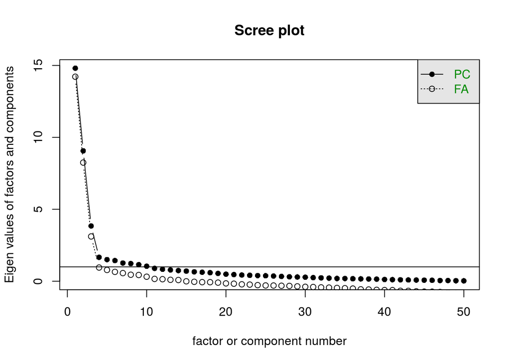

```
## Factor Analysis using method =  pa
## Call: fa(r = eItemDF, nfactors = 2, rotate = "oblimin", scores = "tenBerge",
##     fm = "pa", use = "pairwise.complete.obs")
## Standardized loadings (pattern matrix) based upon correlation matrix
##                    item   PA1   PA2   h2   u2 com
## popular_Self         37  0.86  0.05 0.73 0.27 1.0
## confident_Self       11  0.86 -0.02 0.74 0.26 1.0
## social_Self          45  0.84  0.06 0.71 0.29 1.0
## trendy_Self          48  0.83  0.16 0.68 0.32 1.1
## cool_Self            14  0.79  0.15 0.63 0.37 1.1
## admired_Self          1  0.79  0.13 0.63 0.37 1.1
## attractive_Self       6  0.77 -0.04 0.59 0.41 1.0
## loner_Self           31 -0.75  0.14 0.61 0.39 1.1
## insecure_Self        26 -0.74  0.15 0.59 0.41 1.1
## outgoing_Self        33  0.73  0.09 0.53 0.47 1.0
## flirty_Self          18  0.70  0.18 0.50 0.50 1.1
## leader_Self          29  0.68  0.18 0.48 0.52 1.1
## depressed_Self       15 -0.67  0.23 0.54 0.46 1.2
## lonely_Self          30 -0.67  0.20 0.52 0.48 1.2
## adventurous_Self      2  0.67  0.06 0.44 0.56 1.0
## funny_Self           20  0.62 -0.08 0.40 0.60 1.0
## shy_Self             43 -0.62 -0.11 0.38 0.62 1.1
## awkward_Self          7 -0.62  0.16 0.43 0.57 1.1
## plain_Self           35 -0.58  0.06 0.35 0.65 1.0
## ugly_Self            49 -0.58  0.29 0.46 0.54 1.5
## boring _Self          8 -0.57  0.26 0.42 0.58 1.4
## comforting_Self      10  0.49 -0.30 0.35 0.65 1.6
## pushover_Self        38 -0.46  0.18 0.26 0.74 1.3
## athletic_Self         5  0.39 -0.04 0.16 0.84 1.0
## snobby_Self          44  0.11  0.82 0.67 0.33 1.0
## mean_Self            32  0.09  0.82 0.67 0.33 1.0
## rude_Self            40  0.15  0.79 0.62 0.38 1.1
## agressive_Self        3  0.21  0.73 0.55 0.45 1.2
## selfish_Self         42 -0.03  0.71 0.51 0.49 1.0
## angry_Self            4 -0.14  0.70 0.53 0.47 1.1
## bossy_Self            9  0.37  0.69 0.57 0.43 1.5
## fake_Self            17 -0.15  0.68 0.51 0.49 1.1
## controlling_Self     13  0.43  0.64 0.54 0.46 1.7
## grumpy_Self          23 -0.24  0.62 0.47 0.53 1.3
## considerate_Self     12  0.13 -0.60 0.40 0.60 1.1
```

[output cut: 34 more lines]

```
## The root mean square of the residuals (RMSR) is  0.09
## The df corrected root mean square of the residuals is  0.09
##
## The harmonic number of observations is  99 with the empirical chi square  1854.8  with prob <  1.5e-38
## The total number of observations was  100  with MLE Chi Square =  1973.15  with prob <  3.5e-49
##
## Tucker Lewis Index of factoring reliability =  0.678
## RMSEA index =  0.108  and the 90 % confidence intervals are  0.08 NA
## BIC =  -3212.27
## Fit based upon off diagonal values = 0.93
## Measures of factor score adequacy
##                                                 PA1  PA2
## Correlation of scores with factors             0.99 0.98
## Multiple R square of scores with factors       0.97 0.95
## Minimum correlation of possible factor scores  0.94 0.90
```

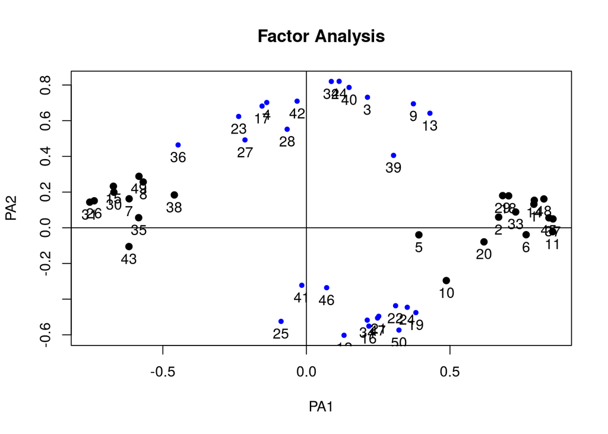

| item | PA1 | PA2 | comm |
| --- | --- | --- | --- |
| popular_Self | 0.86 |  | 0.73 |
| confident_Self | 0.86 |  | 0.74 |
| social_Self | 0.84 |  | 0.71 |
| trendy_Self | 0.83 | 0.16 | 0.68 |
| cool_Self | 0.79 | 0.15 | 0.63 |
| admired_Self | 0.79 | 0.13 | 0.63 |
| attractive_Self | 0.77 |  | 0.59 |
| loner_Self | -0.75 | 0.14 | 0.61 |
| insecure_Self | -0.74 | 0.15 | 0.59 |
| outgoing_Self | 0.73 |  | 0.53 |
| flirty_Self | 0.70 | 0.18 | 0.50 |
| leader_Self | 0.68 | 0.18 | 0.48 |
| depressed_Self | -0.67 | 0.23 | 0.54 |
| lonely_Self | -0.67 | 0.20 | 0.52 |
| adventurous_Self | 0.67 |  | 0.44 |
| funny_Self | 0.62 |  | 0.40 |
| shy_Self | -0.62 | -0.11 | 0.38 |
| awkward_Self | -0.62 | 0.16 | 0.43 |
| plain_Self | -0.58 |  | 0.35 |
| ugly_Self | -0.58 | 0.29 | 0.46 |
| boring _Self | -0.57 | 0.26 | 0.42 |
| comforting_Self | 0.49 | -0.30 | 0.35 |
| pushover_Self | -0.46 | 0.18 | 0.26 |
| athletic_Self | 0.39 |  | 0.16 |
| snobby_Self | 0.11 | 0.82 | 0.67 |
| mean_Self |  | 0.82 | 0.67 |
| rude_Self | 0.15 | 0.79 | 0.62 |
| agressive_Self | 0.21 | 0.73 | 0.55 |
| selfish_Self |  | 0.71 | 0.51 |
| angry_Self | -0.14 | 0.70 | 0.53 |
| bossy_Self | 0.37 | 0.69 | 0.57 |
| fake_Self | -0.15 | 0.68 | 0.51 |
| controlling_Self | 0.43 | 0.64 | 0.54 |
| grumpy_Self | -0.24 | 0.62 | 0.47 |
| considerate_Self | 0.13 | -0.60 | 0.40 |
| welcoming_Self | 0.32 | -0.57 | 0.47 |
| lazy_Self |  | 0.55 | 0.32 |
| fair_Self | 0.22 | -0.55 | 0.37 |
| humble_Self |  | -0.52 | 0.27 |
| patient_Self | 0.21 | -0.52 | 0.33 |
| sympathetic_Self | 0.25 | -0.51 | 0.34 |
| genuine_Self | 0.25 | -0.50 | 0.33 |
| jealous_Self | -0.21 | 0.49 | 0.31 |
| friendly_Self | 0.38 | -0.48 | 0.41 |
| poor_Self | -0.45 | 0.46 | 0.45 |
| honest_Self | 0.35 | -0.45 | 0.35 |
| giving_Self | 0.31 | -0.44 | 0.31 |
| risky_Self | 0.30 | 0.41 | 0.23 |
| studious_Self |  | -0.34 | 0.12 |
| rule-follower_Self |  | -0.32 | 0.10 |

We have 24 items in ‘Admired’ and 26 in ‘Agressive’, so we should drop the 2 worst ‘Agressive’ items: ‘Studious’ and ‘Rule Follower’

```
## Factor Analysis using method =  pa
## Call: fa(r = eItemDF_2drop, nfactors = 2, rotate = "oblimin", scores = "tenBerge",
##     fm = "pa", use = "pairwise.complete.obs")
## Standardized loadings (pattern matrix) based upon correlation matrix
##                  item   PA1   PA2   h2   u2 com
## popular_Self       37  0.86  0.06 0.73 0.27 1.0
## confident_Self     11  0.86 -0.02 0.74 0.26 1.0
## social_Self        44  0.85  0.06 0.71 0.29 1.0
## trendy_Self        46  0.83  0.17 0.69 0.31 1.1
## cool_Self          14  0.79  0.16 0.63 0.37 1.1
## admired_Self        1  0.79  0.14 0.63 0.37 1.1
## attractive_Self     6  0.77 -0.03 0.59 0.41 1.0
## loner_Self         31 -0.75  0.15 0.61 0.39 1.1
## insecure_Self      26 -0.74  0.16 0.59 0.41 1.1
## outgoing_Self      33  0.73  0.09 0.53 0.47 1.0
## flirty_Self        18  0.70  0.18 0.50 0.50 1.1
## leader_Self        29  0.68  0.19 0.48 0.52 1.2
## depressed_Self     15 -0.67  0.24 0.54 0.46 1.2
## lonely_Self        30 -0.67  0.21 0.52 0.48 1.2
## adventurous_Self    2  0.67  0.06 0.45 0.55 1.0
## funny_Self         20  0.62 -0.07 0.40 0.60 1.0
## awkward_Self        7 -0.62  0.17 0.43 0.57 1.2
## shy_Self           42 -0.61 -0.09 0.38 0.62 1.0
## ugly_Self          47 -0.59  0.29 0.46 0.54 1.5
## plain_Self         35 -0.58  0.06 0.35 0.65 1.0
## boring _Self        8 -0.57  0.26 0.42 0.58 1.4
## comforting_Self    10  0.49 -0.29 0.35 0.65 1.6
## pushover_Self      38 -0.46  0.20 0.27 0.73 1.4
## athletic_Self       5  0.39 -0.04 0.16 0.84 1.0
## snobby_Self        43  0.11  0.83 0.69 0.31 1.0
## mean_Self          32  0.08  0.83 0.68 0.32 1.0
## rude_Self          40  0.14  0.80 0.63 0.37 1.1
## agressive_Self      3  0.21  0.73 0.56 0.44 1.2
## angry_Self          4 -0.14  0.71 0.54 0.46 1.1
## selfish_Self       41 -0.04  0.71 0.51 0.49 1.0
## bossy_Self          9  0.37  0.71 0.59 0.41 1.5
## fake_Self          17 -0.16  0.68 0.51 0.49 1.1
## controlling_Self   13  0.43  0.66 0.56 0.44 1.7
## grumpy_Self        23 -0.24  0.64 0.49 0.51 1.3
## considerate_Self   12  0.14 -0.59 0.38 0.62 1.1
```

[output cut: 32 more lines]

```
## The root mean square of the residuals (RMSR) is  0.09
## The df corrected root mean square of the residuals is  0.09
##
## The harmonic number of observations is  99 with the empirical chi square  1627.46  with prob <  2.3e-29
## The total number of observations was  100  with MLE Chi Square =  1827.22  with prob <  6.7e-47
##
## Tucker Lewis Index of factoring reliability =  0.692
## RMSEA index =  0.109  and the 90 % confidence intervals are  0.081 NA
## BIC =  -2929.92
## Fit based upon off diagonal values = 0.94
## Measures of factor score adequacy
##                                                 PA1  PA2
## Correlation of scores with factors             0.99 0.98
## Multiple R square of scores with factors       0.97 0.95
## Minimum correlation of possible factor scores  0.94 0.91
```

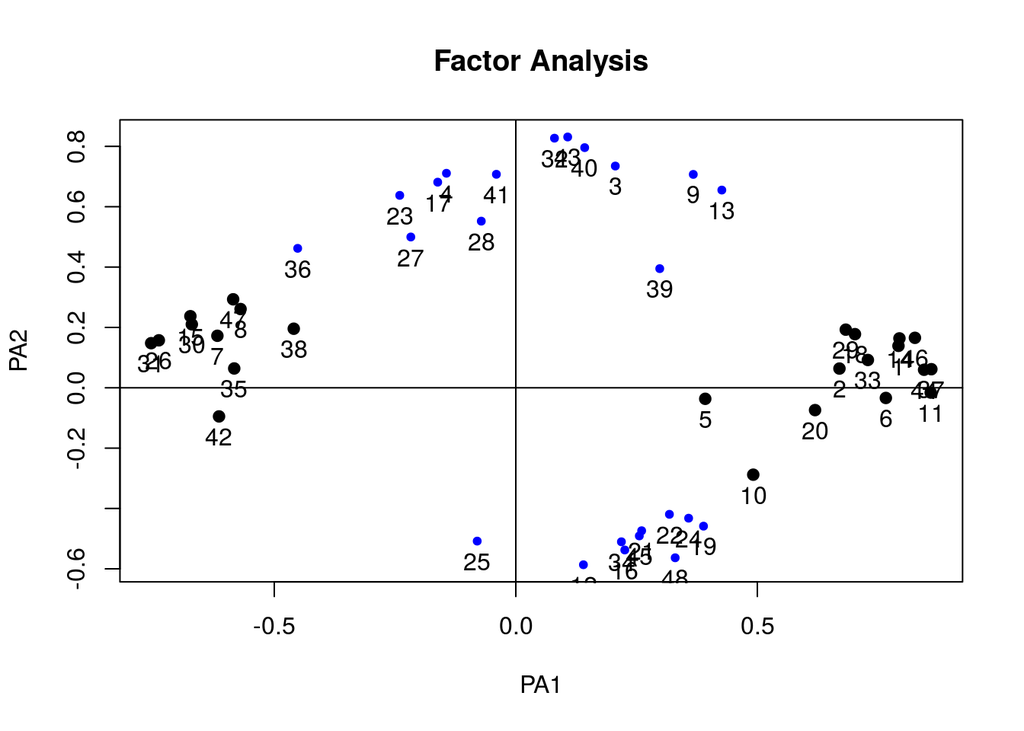

| item | PA1 | PA2 | comm |
| --- | --- | --- | --- |
| popular_Self | 0.86 |  | 0.73 |
| confident_Self | 0.86 |  | 0.74 |
| social_Self | 0.85 |  | 0.71 |
| trendy_Self | 0.83 | 0.17 | 0.69 |
| cool_Self | 0.79 | 0.16 | 0.63 |
| admired_Self | 0.79 | 0.14 | 0.63 |
| attractive_Self | 0.77 |  | 0.59 |
| loner_Self | -0.75 | 0.15 | 0.61 |
| insecure_Self | -0.74 | 0.16 | 0.59 |
| outgoing_Self | 0.73 |  | 0.53 |
| flirty_Self | 0.70 | 0.18 | 0.50 |
| leader_Self | 0.68 | 0.19 | 0.48 |
| depressed_Self | -0.67 | 0.24 | 0.54 |
| lonely_Self | -0.67 | 0.21 | 0.52 |
| adventurous_Self | 0.67 |  | 0.45 |
| funny_Self | 0.62 |  | 0.40 |
| awkward_Self | -0.62 | 0.17 | 0.43 |
| shy_Self | -0.61 |  | 0.38 |
| ugly_Self | -0.59 | 0.29 | 0.46 |
| plain_Self | -0.58 |  | 0.35 |
| boring _Self | -0.57 | 0.26 | 0.42 |
| comforting_Self | 0.49 | -0.29 | 0.35 |
| pushover_Self | -0.46 | 0.20 | 0.27 |
| athletic_Self | 0.39 |  | 0.16 |
| snobby_Self | 0.11 | 0.83 | 0.69 |
| mean_Self |  | 0.83 | 0.68 |
| rude_Self | 0.14 | 0.80 | 0.63 |
| agressive_Self | 0.21 | 0.73 | 0.56 |
| angry_Self | -0.14 | 0.71 | 0.54 |
| selfish_Self |  | 0.71 | 0.51 |
| bossy_Self | 0.37 | 0.71 | 0.59 |
| fake_Self | -0.16 | 0.68 | 0.51 |
| controlling_Self | 0.43 | 0.66 | 0.56 |
| grumpy_Self | -0.24 | 0.64 | 0.49 |
| considerate_Self | 0.14 | -0.59 | 0.38 |
| welcoming_Self | 0.33 | -0.56 | 0.46 |
| lazy_Self |  | 0.55 | 0.32 |
| fair_Self | 0.23 | -0.54 | 0.36 |
| patient_Self | 0.22 | -0.51 | 0.33 |
| humble_Self |  | -0.51 | 0.26 |
| jealous_Self | -0.22 | 0.50 | 0.32 |
| sympathetic_Self | 0.26 | -0.49 | 0.33 |
| genuine_Self | 0.26 | -0.47 | 0.31 |
| poor_Self | -0.45 | 0.46 | 0.45 |
| friendly_Self | 0.39 | -0.46 | 0.39 |
| honest_Self | 0.36 | -0.43 | 0.34 |
| giving_Self | 0.32 | -0.42 | 0.30 |
| risky_Self | 0.30 | 0.39 | 0.22 |

For reference, the original EFA with items that also appear above in bold.

Original EFA, retained items bolded

| item | PA1 | PA2 | comm |
| --- | --- | --- | --- |
| **popular_Self** | 0.85 |  | 0.730 |
| **social_Self** | 0.84 |  | 0.714 |
| **confident_Self** | 0.84 |  | 0.740 |
| **trendy_Self** | 0.83 | -0.10 | 0.674 |
| **cool_Self** | 0.81 |  | 0.641 |
| **admired_Self** | 0.80 |  | 0.635 |
| **attractive_Self** | 0.76 | 0.12 | 0.620 |
| **outgoing_Self** | 0.73 |  | 0.520 |
| **flirty_Self** | 0.72 | -0.14 | 0.511 |
| **loner_Self** | -0.71 | -0.15 | 0.567 |
| **leader_Self** | 0.70 | -0.12 | 0.482 |
| **insecure_Self** | -0.69 | -0.14 | 0.537 |
| **adventurous_Self** | 0.69 |  | 0.472 |
| **shy_Self** | -0.63 | 0.13 | 0.383 |
| **lonely_Self** | -0.62 | -0.17 | 0.452 |
| **depressed_Self** | -0.62 | -0.21 | 0.467 |
| **funny_Self** | 0.61 | 0.15 | 0.420 |
| daring_Self | 0.58 | -0.20 | 0.342 |
| **awkward_Self** | -0.57 | -0.13 | 0.371 |
| **plain_Self** | -0.56 |  | 0.329 |
| **ugly_Self** | -0.53 | -0.31 | 0.439 |
| **boring_Self** | -0.51 | -0.25 | 0.366 |
| **comforting_Self** | 0.44 | 0.36 | 0.383 |
| **pushover_Self** | -0.43 | -0.17 | 0.238 |
| **athletic_Self** | 0.39 |  | 0.169 |
| **mean_Self** | 0.20 | -0.79 | 0.607 |
| **snobby_Self** | 0.23 | -0.78 | 0.608 |
| **rude_Self** | 0.25 | -0.74 | 0.547 |
| nice_Self | 0.15 | 0.73 | 0.587 |
| **considerate_Self** |  | 0.71 | 0.525 |
| **fake_Self** |  | -0.70 | 0.500 |
| **agressive_Self** | 0.31 | -0.69 | 0.503 |
| **selfish_Self** |  | -0.69 | 0.461 |
| **welcoming_Self** | 0.24 | 0.65 | 0.538 |
| **bossy_Self** | 0.47 | -0.65 | 0.535 |
| **angry_Self** |  | -0.64 | 0.416 |
| **fair_Self** | 0.14 | 0.62 | 0.433 |
| **genuine_Self** | 0.18 | 0.61 | 0.441 |
| caring_Self | 0.24 | 0.60 | 0.470 |
| helpful_Self | 0.31 | 0.60 | 0.512 |
| **sympathetic_Self** | 0.18 | 0.59 | 0.420 |
| trustworthy_Self | 0.29 | 0.59 | 0.492 |
| **friendly_Self** | 0.32 | 0.58 | 0.498 |
| **humble_Self** | -0.16 | 0.58 | 0.327 |
| **grumpy_Self** | -0.14 | -0.57 | 0.376 |
| loyal_Self |  | 0.57 | 0.350 |
| calm_Self | 0.24 | 0.56 | 0.421 |
| **patient_Self** | 0.14 | 0.56 | 0.361 |
| **controlling_Self** | 0.51 | -0.56 | 0.475 |
| **giving_Self** | 0.25 | 0.53 | 0.389 |
| **lazy_Self** |  | -0.52 | 0.266 |
| **honest_Self** | 0.28 | 0.51 | 0.387 |
| respectful_Self | 0.14 | 0.49 | 0.288 |
| **poor_Self** | -0.36 | -0.46 | 0.405 |
| **jealous_Self** | -0.14 | -0.44 | 0.236 |
| smart_Self | 0.13 | 0.41 | 0.202 |
| studious_Self |  | 0.40 | 0.162 |
| motivated_Self | 0.27 | 0.39 | 0.263 |
| rule-follower_Self |  | 0.39 | 0.150 |
| **risky_Self** | 0.38 | -0.38 | 0.242 |
| stubborn_Self | 0.17 | -0.28 | 0.088 |
| dependent_Self |  | -0.18 | 0.039 |

## Pick items by X-loading and Communality

We could also pick items based on cross loadings (minimizing) and communality (maximizing).

| item | max | maxPA | ssXload | comm | scalemax | scalessX | scalecomm | crit |
| --- | --- | --- | --- | --- | --- | --- | --- | --- |
| **comforting_Self** | 0.44 | PA1 | 0.13 | 0.38 | -1.09 | -1.70 | -0.31 | -1.03 |
| **pushover_Self** | -0.43 | PA1 | 0.03 | 0.24 | -1.20 | 0.00 | -1.25 | -0.82 |
| **athletic_Self** | 0.39 | PA1 | 0.01 | 0.17 | -1.49 | 0.75 | -1.70 | -0.81 |
| **boring_Self** | -0.51 | PA1 | 0.06 | 0.37 | -0.61 | -0.66 | -0.42 | -0.56 |
| **ugly_Self** | -0.53 | PA1 | 0.10 | 0.44 | -0.47 | -1.27 | 0.05 | -0.56 |
| daring_Self | 0.58 | PA1 | 0.04 | 0.34 | -0.12 | -0.29 | -0.58 | -0.33 |
| **awkward_Self** | -0.57 | PA1 | 0.02 | 0.37 | -0.19 | 0.34 | -0.39 | -0.08 |
| **depressed_Self** | -0.62 | PA1 | 0.04 | 0.47 | 0.11 | -0.36 | 0.24 | -0.01 |
| **funny_Self** | 0.61 | PA1 | 0.02 | 0.42 | 0.04 | 0.18 | -0.07 | 0.05 |
| **shy_Self** | -0.63 | PA1 | 0.02 | 0.38 | 0.18 | 0.32 | -0.31 | 0.06 |
| **plain_Self** | -0.56 | PA1 | 0.00 | 0.33 | -0.25 | 1.12 | -0.66 | 0.07 |
| **lonely_Self** | -0.62 | PA1 | 0.03 | 0.45 | 0.16 | 0.02 | 0.14 | 0.11 |
| **leader_Self** | 0.70 | PA1 | 0.01 | 0.48 | 0.72 | 0.47 | 0.33 | 0.51 |
| **insecure_Self** | -0.69 | PA1 | 0.02 | 0.54 | 0.66 | 0.23 | 0.69 | 0.53 |
| **flirty_Self** | 0.72 | PA1 | 0.02 | 0.51 | 0.87 | 0.26 | 0.52 | 0.55 |
| **loner_Self** | -0.71 | PA1 | 0.02 | 0.57 | 0.79 | 0.19 | 0.88 | 0.62 |
| **adventurous_Self** | 0.69 | PA1 | 0.00 | 0.47 | 0.60 | 1.44 | 0.27 | 0.77 |
| **outgoing_Self** | 0.73 | PA1 | 0.00 | 0.52 | 0.88 | 1.19 | 0.58 | 0.88 |
| **attractive_Self** | 0.76 | PA1 | 0.02 | 0.62 | 1.09 | 0.41 | 1.23 | 0.91 |
| **cool_Self** | 0.81 | PA1 | 0.00 | 0.64 | 1.46 | 0.92 | 1.36 | 1.24 |
| **trendy_Self** | 0.83 | PA1 | 0.01 | 0.67 | 1.62 | 0.58 | 1.58 | 1.26 |
| **admired_Self** | 0.80 | PA1 | 0.00 | 0.63 | 1.42 | 1.07 | 1.32 | 1.27 |
| **confident_Self** | 0.84 | PA1 | 0.01 | 0.74 | 1.68 | 0.71 | 2.00 | 1.46 |
| **social_Self** | 0.84 | PA1 | 0.00 | 0.71 | 1.70 | 1.41 | 1.84 | 1.65 |
| **popular_Self** | 0.85 | PA1 | 0.00 | 0.73 | 1.75 | 1.32 | 1.94 | 1.67 |
| **risky_Self** | -0.38 | PA2 | 0.14 | 0.24 | -1.52 | -1.85 | -1.23 | -1.53 |
| stubborn_Self | -0.28 | PA2 | 0.03 | 0.09 | -2.27 | 0.05 | -2.23 | -1.48 |
| dependent_Self | -0.18 | PA2 | 0.00 | 0.04 | -2.92 | 1.05 | -2.54 | -1.47 |
| motivated_Self | 0.39 | PA2 | 0.07 | 0.26 | -1.45 | -0.88 | -1.09 | -1.14 |
| **controlling_Self** | -0.56 | PA2 | 0.26 | 0.47 | -0.31 | -3.01 | 0.28 | -1.01 |
| **poor_Self** | -0.46 | PA2 | 0.13 | 0.40 | -0.96 | -1.71 | -0.17 | -0.95 |
| smart_Self | 0.41 | PA2 | 0.02 | 0.20 | -1.34 | 0.34 | -1.49 | -0.83 |
| **rule-follower_Self** | 0.39 | PA2 | 0.01 | 0.15 | -1.46 | 0.83 | -1.83 | -0.82 |
| **jealous_Self** | -0.44 | PA2 | 0.02 | 0.24 | -1.10 | 0.28 | -1.27 | -0.70 |
| **honest_Self** | 0.51 | PA2 | 0.08 | 0.39 | -0.62 | -0.95 | -0.29 | -0.62 |
| **studious_Self** | 0.40 | PA2 | 0.00 | 0.16 | -1.41 | 1.34 | -1.75 | -0.60 |
| **bossy_Self** | -0.65 | PA2 | 0.22 | 0.53 | 0.32 | -2.63 | 0.67 | -0.55 |
| **giving_Self** | 0.53 | PA2 | 0.06 | 0.39 | -0.48 | -0.70 | -0.27 | -0.49 |
| respectful_Self | 0.49 | PA2 | 0.02 | 0.29 | -0.74 | 0.27 | -0.93 | -0.47 |
| **friendly_Self** | 0.58 | PA2 | 0.10 | 0.50 | -0.14 | -1.29 | 0.43 | -0.33 |
| calm_Self | 0.56 | PA2 | 0.06 | 0.42 | -0.25 | -0.61 | -0.06 | -0.31 |
| **humble_Self** | 0.58 | PA2 | 0.03 | 0.33 | -0.17 | 0.10 | -0.67 | -0.25 |
| helpful_Self | 0.60 | PA2 | 0.10 | 0.51 | -0.03 | -1.22 | 0.53 | -0.24 |
| trustworthy_Self | 0.59 | PA2 | 0.08 | 0.49 | -0.06 | -1.05 | 0.40 | -0.24 |
| **patient_Self** | 0.56 | PA2 | 0.02 | 0.36 | -0.26 | 0.30 | -0.45 | -0.14 |
| caring_Self | 0.60 | PA2 | 0.06 | 0.47 | 0.00 | -0.65 | 0.25 | -0.13 |
| **grumpy_Self** | -0.57 | PA2 | 0.02 | 0.38 | -0.19 | 0.25 | -0.36 | -0.10 |
| **lazy_Self** | -0.52 | PA2 | 0.00 | 0.27 | -0.58 | 1.40 | -1.07 | -0.08 |
| **sympathetic_Self** | 0.59 | PA2 | 0.03 | 0.42 | -0.05 | -0.07 | -0.07 | -0.06 |
| **agressive_Self** | -0.69 | PA2 | 0.10 | 0.50 | 0.63 | -1.27 | 0.47 | -0.06 |
| loyal_Self | 0.57 | PA2 | 0.01 | 0.35 | -0.23 | 0.65 | -0.53 | -0.04 |
| **genuine_Self** | 0.61 | PA2 | 0.03 | 0.44 | 0.06 | -0.10 | 0.06 | 0.01 |
| **fair_Self** | 0.62 | PA2 | 0.02 | 0.43 | 0.14 | 0.27 | 0.01 | 0.14 |
| **welcoming_Self** | 0.65 | PA2 | 0.06 | 0.54 | 0.37 | -0.62 | 0.70 | 0.15 |
| **rude_Self** | -0.74 | PA2 | 0.06 | 0.55 | 0.97 | -0.70 | 0.76 | 0.34 |
| **angry_Self** | -0.64 | PA2 | 0.00 | 0.42 | 0.26 | 1.20 | -0.10 | 0.46 |
| **selfish_Self** | -0.69 | PA2 | 0.01 | 0.46 | 0.61 | 0.84 | 0.19 | 0.55 |
| **snobby_Self** | -0.78 | PA2 | 0.05 | 0.61 | 1.28 | -0.52 | 1.15 | 0.64 |
| nice_Self | 0.73 | PA2 | 0.02 | 0.59 | 0.88 | 0.16 | 1.01 | 0.68 |
| **fake_Self** | -0.70 | PA2 | 0.00 | 0.50 | 0.67 | 1.06 | 0.45 | 0.73 |
| **mean_Self** | -0.79 | PA2 | 0.04 | 0.61 | 1.30 | -0.26 | 1.14 | 0.73 |
| **considerate_Self** | 0.71 | PA2 | 0.00 | 0.52 | 0.79 | 1.03 | 0.61 | 0.81 |

Based on this table, we could drop items with low scores on ‘crit’, which is just an average of Z scores for each of our criteria (main factor loading, cross-loadings, and communality). This way is is more of an art than a mathematical method, so….

I’m going to set this route aside for now, because the SPCA is made for item selection, especially if we get good prediction below. (The basis behind SPCA is the same as PCA/EFA, which is is to identify loadings on factors that capture the maximum amount of variance in the data. In light of that, the 48 items should do what we want).

## Regressions with new items

### 48 items: Regressing Controversial Status

```
##
## Call: rlm(formula = selfPopDat[, c("SelfPop_1")] ~ predict(eItemFA_2drop,
##     eitemDF_imputed))
## Residuals:
##      Min       1Q   Median       3Q      Max
## -3.15928 -0.67654 -0.04381  0.65041  3.76354
##
## Coefficients:
##                                          Value   Std. Error t value
## (Intercept)                               2.3158  0.1194    19.3999
## predict(eItemFA_2drop, eitemDF_imputed)1  0.1550  0.1203     1.2884
## predict(eItemFA_2drop, eitemDF_imputed)2  1.0287  0.1203     8.5520
##
## Residual standard error: 0.9919 on 95 degrees of freedom
##   (2 observations deleted due to missingness)
```

Results from bootstrap estimates: Controversial status is significantly predicted by and higher aggression scores (2; the sign shifted again, btw). Estimates for ‘admired’ are barely just include 0 in the CI (1).

Controversial status relation with component scores, bootstrapped CIs

| component | est | lower 95% | upper 95% |
| --- | --- | --- | --- |
| 1 | 0.16 | -0.02 | 0.37 |
| 2 | 1.03 | 0.74 | 1.27 |

### 48 item: Regressing Accepted Status

Here’s the raw output for an rlm of accepted status on the component scores. Again, scroll down for a nice table.

```
##
## Call: rlm(formula = selfPopDat[, c("SelfPop_2")] ~ predict(eItemFA_2drop,
##     eitemDF_imputed))
## Residuals:
##      Min       1Q   Median       3Q      Max
## -3.69001 -0.71057  0.05377  0.49039  2.20488
##
## Coefficients:
##                                          Value   Std. Error t value
## (Intercept)                               3.5805  0.1146    31.2524
## predict(eItemFA_2drop, eitemDF_imputed)1  1.2717  0.1152    11.0375
## predict(eItemFA_2drop, eitemDF_imputed)2  0.0383  0.1154     0.3316
##
## Residual standard error: 0.8166 on 97 degrees of freedom
```

Accepted status is significantly predicted by higher ‘Admired’ (1), and not by ‘Aggressive’ (2).

Accepted status relation with component scores, bootstrapped CIs

[output not shown]

### 48 items collapsed into 2 scales

Let’s see how this scale works if we just use them as a scale, taking the mean across items (we’ve been using predicted factor scores before).

See raw summary, and below that, tables of bootstrapped CIs. It’s what we’ve come to expect.

```
##
## Call: rlm(formula = SelfPop_1 ~ 1 + admired + agressive, data = selfRateSPCAScaleScores)
## Residuals:
##     Min      1Q  Median      3Q     Max
## -3.4276 -0.7365 -0.1132  0.7040  3.5158
##
## Coefficients:
##             Value   Std. Error t value
## (Intercept) -1.7998  0.6800    -2.6469
## admired      0.2748  0.1215     2.2620
## agressive    1.2584  0.1582     7.9549
##
## Residual standard error: 1.104 on 95 degrees of freedom
##   (2 observations deleted due to missingness)
```

```
##
## Call: rlm(formula = SelfPop_2 ~ 1 + admired + agressive, data = selfRateSPCAScaleScores)
## Residuals:
##     Min      1Q  Median      3Q     Max
## -3.3058 -0.6884  0.1221  0.5658  2.1021
##
## Coefficients:
##             Value   Std. Error t value
## (Intercept) -1.0740  0.6319    -1.6996
## admired      1.1472  0.1119    10.2495
## agressive    0.1343  0.1458     0.9211
##
## Residual standard error: 0.9276 on 97 degrees of freedom
```

```
## Call:corr.test(x = select(selfRateSPCAScaleScores, matches("SelfPop")),
##     y = select(selfRateSPCAScaleScores, admired, agressive),
##     use = "pairwise.complete.obs", method = "spearman", adjust = "none")
## Correlation matrix
##           admired agressive
## SelfPop_1    0.06      0.61
## SelfPop_2    0.71     -0.18
## Sample Size
##           admired agressive
## SelfPop_1      98        98
## SelfPop_2     100       100
##           admired agressive
## SelfPop_1    0.56      0.00
## SelfPop_2    0.00      0.07
##
##  To see confidence intervals of the correlations, print with the short=FALSE option
```

Controversial status relation with scale scores, bootstrapped CIs

|  | est | lower 95% | upper 95% |
| --- | --- | --- | --- |
| d[, 2:col]admired | 0.27 | 0.10 | 0.47 |
| d[, 2:col]agressive | 1.26 | 0.87 | 1.61 |

Accepted status relation with scale scores, bootstrapped CIs

|  | est | lower 95% | upper 95% |
| --- | --- | --- | --- |
| d[, 2:col]admired | 1.15 | 0.93 | 1.34 |
| d[, 2:col]agressive | 0.13 | -0.16 | 0.37 |

Quick check for binarizing, which is what we’d see from scan data

```
##
## Call: rlm(formula = SelfPop_1 ~ 1 + admired + agressive, data = selfRateSPCAScaleScoresBin)
## Residuals:
##     Min      1Q  Median      3Q     Max
## -3.1848 -0.7234 -0.2798  0.8111  3.3750
##
## Coefficients:
##             Value  Std. Error t value
## (Intercept) 0.8956 0.3609     2.4818
## admired     0.8166 0.4849     1.6843
## agressive   4.2019 0.6378     6.5880
##
## Residual standard error: 1.168 on 95 degrees of freedom
##   (2 observations deleted due to missingness)
```

```
##
## Call: rlm(formula = SelfPop_2 ~ 1 + admired + agressive, data = selfRateSPCAScaleScoresBin)
## Residuals:
##     Min      1Q  Median      3Q     Max
## -3.2251 -0.6696  0.0716  0.8064  2.5875
##
## Coefficients:
##             Value   Std. Error t value
## (Intercept)  1.3305  0.3133     4.2465
## admired      3.8633  0.4177     9.2499
## agressive   -0.0233  0.5523    -0.0421
##
## Residual standard error: 1.185 on 97 degrees of freedom
```

```
## Call:corr.test(x = select(selfRateSPCAScaleScoresBin, matches("SelfPop")),
##     y = select(selfRateSPCAScaleScoresBin, admired, agressive),
##     use = "pairwise.complete.obs", method = "spearman", adjust = "none")
## Correlation matrix
##           admired agressive
## SelfPop_1    0.07      0.56
## SelfPop_2    0.68     -0.18
## Sample Size
##           admired agressive
## SelfPop_1      98        98
## SelfPop_2     100       100
##           admired agressive
## SelfPop_1    0.52      0.00
## SelfPop_2    0.00      0.07
##
##  To see confidence intervals of the correlations, print with the short=FALSE option
```

The Aggressive scale, predicts Controversial High Status, and holding it constant, the Admired scale also predicts Controversial status, though less strongly. The Admired scale predicts Accepted High Status.

### A Little CFA

Grain of salt: We don’t think this should actually reflect the constructs in our data – we know there are probably actually 4 factors, but this tells us how things look if we were to really go for this model. It is not the worst I’ve ever seen!

```
## admired=~admired_Self+adventurous_Self+athletic_Self+attractive_Self+awkward_Self+boring_Self+comforting_Self+confident_Self+cool_Self+depressed_Self+flirty_Self+funny_Self+insecure_Self+leader_Self+lonely_Self+loner_Self+outgoing_Self+plain_Self+popular_Self+pushover_Self+shy_Self+social_Self+tr…
## agressive=~agressive_Self+angry_Self+bossy_Self+considerate_Self+controlling_Self+fair_Self+fake_Self+friendly_Self+genuine_Self+giving_Self+grumpy_Self+honest_Self+humble_Self+jealous_Self+lazy_Self+mean_Self+patient_Self+poor_Self+risky_Self+rude_Self+selfish_Self+snobby_Self+sympathetic_Self+w…
```

```
## lavaan (0.5-18) converged normally after  39 iterations
##
##                                                   Used       Total
##   Number of observations                            95         100
##
##   Estimator                                         ML
##   Minimum Function Test Statistic             2588.082
##   Degrees of freedom                              1079
##   P-value (Chi-square)                           0.000
##
## Model test baseline model:
##
##   Minimum Function Test Statistic             4781.739
##   Degrees of freedom                              1128
##   P-value                                        0.000
##
## User model versus baseline model:
##
##   Comparative Fit Index (CFI)                    0.587
##   Tucker-Lewis Index (TLI)                       0.568
##
## Loglikelihood and Information Criteria:
##
##   Loglikelihood user model (H0)              -7045.058
##   Loglikelihood unrestricted model (H1)      -5751.017
##
##   Number of free parameters                         97
##   Akaike (AIC)                               14284.116
##   Bayesian (BIC)                             14531.842
##   Sample-size adjusted Bayesian (BIC)        14225.592
##
## Root Mean Square Error of Approximation:
##
##   RMSEA                                          0.121
##   90 Percent Confidence Interval          0.115  0.127
##   P-value RMSEA <= 0.05                          0.000
##
## Standardized Root Mean Square Residual:
##
##   SRMR                                           0.163
```

[output cut: 99 more lines]

```
##     honest_Self       1.075    0.159                      1.075    0.746
##     humble_Self       1.113    0.165                      1.113    0.745
##     jealous_Self      1.352    0.201                      1.352    0.691
##     lazy_Self         1.631    0.243                      1.631    0.702
##     mean_Self         0.596    0.098                      0.596    0.331
##     patient_Self      1.306    0.194                      1.306    0.708
##     poor_Self         1.758    0.260                      1.758    0.743
##     risky_Self        1.781    0.260                      1.781    0.885
##     rude_Self         0.651    0.103                      0.651    0.405
##     selfish_Self      0.953    0.148                      0.953    0.480
##     snobby_Self       0.812    0.131                      0.812    0.377
##     sympathtc_Slf     1.197    0.178                      1.197    0.703
##     welcoming_Slf     0.870    0.132                      0.870    0.592
##     admired           1.288    0.295                      1.000    1.000
##     agressive         0.943    0.251                      1.000    1.000
```

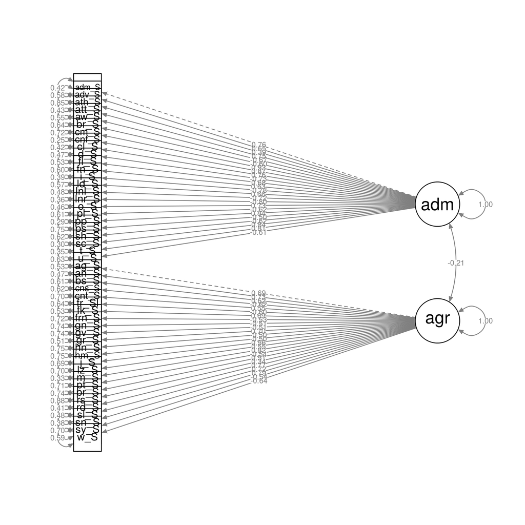

Estimates of reliability vary below between the CFA and the alphas on the raw scales, but I’m not sure why (probably because the CFA relaibility takes into account loadings and other things).

```
##          admired agressive     total
## alpha  0.5402874 0.7112545 0.7814680
## omega  0.3693421 0.5822450 0.4363278
## omega2 0.3693421 0.5822450 0.4363278
## omega3 0.1430795 0.2741168 0.1005633
## avevar 0.4933667 0.3822614 0.4467360
```

```
##
## Reliability analysis
## Call: alpha(x = dataCFA[, itemScaleGroupsCFA$item[itemScaleGroupsCFA$maxPA ==
##     "PA1"]], check.keys = T)
##
##   raw_alpha std.alpha G6(smc) average_r S/N   ase mean  sd
##       0.95      0.96    0.97      0.47  21 0.012  3.8 1.1
##
##  lower alpha upper     95% confidence boundaries
## 0.93 0.95 0.98
##
##  Reliability if an item is dropped:
##                  raw_alpha std.alpha G6(smc) average_r S/N alpha se
## admired_Self          0.95      0.95    0.97      0.47  20    0.013
## adventurous_Self      0.95      0.95    0.97      0.47  21    0.013
## athletic_Self         0.96      0.96    0.97      0.49  22    0.013
## attractive_Self       0.95      0.95    0.97      0.47  20    0.013
## awkward_Self-         0.95      0.95    0.97      0.47  20    0.013
## boring_Self-          0.95      0.95    0.97      0.47  21    0.013
## comforting_Self       0.95      0.96    0.97      0.48  21    0.013
## confident_Self        0.95      0.95    0.97      0.46  20    0.013
## cool_Self             0.95      0.95    0.97      0.47  20    0.013
## depressed_Self-       0.95      0.95    0.97      0.47  20    0.013
## flirty_Self           0.95      0.95    0.97      0.47  21    0.013
## funny_Self            0.95      0.95    0.97      0.47  21    0.013
## insecure_Self-        0.95      0.95    0.97      0.46  20    0.013
## leader_Self           0.95      0.95    0.97      0.47  21    0.013
## lonely_Self-          0.95      0.95    0.97      0.47  20    0.013
## loner_Self-           0.95      0.95    0.97      0.46  20    0.013
## outgoing_Self         0.95      0.95    0.97      0.47  20    0.013
## plain_Self-           0.95      0.95    0.97      0.47  21    0.013
## popular_Self          0.95      0.95    0.97      0.46  20    0.013
## pushover_Self-        0.95      0.96    0.97      0.48  21    0.013
## shy_Self-             0.95      0.95    0.97      0.47  21    0.013
## social_Self           0.95      0.95    0.97      0.46  20    0.013
## trendy_Self           0.95      0.95    0.97      0.46  20    0.013
## ugly_Self-            0.95      0.95    0.97      0.47  21    0.013
##
##  Item statistics
##                    n raw.r std.r r.cor r.drop mean  sd
```

[output cut: 36 more lines]

```
## depressed_Self   0.26 0.18 0.18 0.15 0.12 0.10 0.01
## flirty_Self      0.21 0.21 0.14 0.19 0.16 0.08 0.01
## funny_Self       0.04 0.07 0.13 0.31 0.30 0.15 0.00
## insecure_Self    0.19 0.15 0.15 0.17 0.17 0.17 0.00
## leader_Self      0.14 0.22 0.17 0.22 0.16 0.09 0.00
## lonely_Self      0.22 0.16 0.19 0.21 0.10 0.12 0.00
## loner_Self       0.25 0.18 0.14 0.18 0.13 0.12 0.00
## outgoing_Self    0.19 0.14 0.14 0.15 0.22 0.16 0.00
## plain_Self       0.18 0.17 0.22 0.18 0.14 0.10 0.01
## popular_Self     0.17 0.16 0.21 0.23 0.10 0.12 0.01
## pushover_Self    0.27 0.18 0.10 0.21 0.17 0.06 0.01
## shy_Self         0.14 0.12 0.13 0.19 0.20 0.22 0.00
## social_Self      0.11 0.11 0.13 0.26 0.19 0.20 0.00
## trendy_Self      0.15 0.16 0.13 0.28 0.18 0.09 0.01
## ugly_Self        0.35 0.27 0.17 0.10 0.07 0.04 0.00
```

```
##
## Reliability analysis
## Call: alpha(x = dataCFA[, itemScaleGroupsCFA$item[itemScaleGroupsCFA$maxPA ==
##     "PA2"]], check.keys = T)
##
##   raw_alpha std.alpha G6(smc) average_r S/N   ase mean   sd
##       0.93      0.93    0.96      0.37  14 0.016  2.5 0.85
##
##  lower alpha upper     95% confidence boundaries
## 0.9 0.93 0.96
##
##  Reliability if an item is dropped:
##                   raw_alpha std.alpha G6(smc) average_r S/N alpha se
## agressive_Self         0.93      0.93    0.96      0.36  13    0.017
## angry_Self             0.93      0.93    0.96      0.36  13    0.017
## bossy_Self             0.93      0.93    0.96      0.37  13    0.016
## considerate_Self-      0.93      0.93    0.96      0.36  13    0.017
## controlling_Self       0.93      0.93    0.96      0.37  14    0.016
## fair_Self-             0.93      0.93    0.96      0.37  13    0.017
## fake_Self              0.93      0.93    0.96      0.36  13    0.017
## friendly_Self-         0.93      0.93    0.96      0.37  13    0.016
## genuine_Self-          0.93      0.93    0.96      0.37  13    0.016
## giving_Self-           0.93      0.93    0.96      0.37  14    0.016
## grumpy_Self            0.93      0.93    0.96      0.36  13    0.017
## honest_Self-           0.93      0.93    0.96      0.37  14    0.016
## humble_Self-           0.93      0.93    0.96      0.37  14    0.016
## jealous_Self           0.93      0.93    0.96      0.37  14    0.016
## lazy_Self              0.93      0.93    0.96      0.37  13    0.016
## mean_Self              0.93      0.93    0.96      0.36  13    0.017
## patient_Self-          0.93      0.93    0.96      0.37  13    0.016
## poor_Self              0.93      0.93    0.96      0.37  14    0.016
## risky_Self             0.93      0.93    0.96      0.38  14    0.016
## rude_Self              0.93      0.93    0.96      0.36  13    0.017
## selfish_Self           0.93      0.93    0.96      0.36  13    0.017
## snobby_Self            0.93      0.93    0.96      0.36  13    0.017
## sympathetic_Self-      0.93      0.93    0.96      0.37  13    0.016
## welcoming_Self-        0.93      0.93    0.96      0.36  13    0.017
##
##  Item statistics
##                     n raw.r std.r r.cor r.drop mean  sd
```

[output cut: 36 more lines]

```
## giving_Self      0.01 0.10 0.03 0.31 0.28 0.27 0.00
## grumpy_Self      0.29 0.26 0.14 0.15 0.11 0.04 0.01
## honest_Self      0.01 0.06 0.11 0.20 0.37 0.24 0.01
## humble_Self      0.04 0.02 0.15 0.31 0.29 0.19 0.00
## jealous_Self     0.24 0.14 0.28 0.20 0.10 0.04 0.00
## lazy_Self        0.31 0.24 0.12 0.19 0.08 0.05 0.01
## mean_Self        0.46 0.17 0.16 0.11 0.09 0.01 0.00
## patient_Self     0.03 0.12 0.13 0.27 0.28 0.16 0.01
## poor_Self        0.29 0.15 0.22 0.14 0.17 0.03 0.00
## risky_Self       0.21 0.22 0.23 0.18 0.12 0.04 0.00
## rude_Self        0.43 0.23 0.15 0.12 0.07 0.00 0.00
## selfish_Self     0.28 0.24 0.16 0.19 0.10 0.02 0.01
## snobby_Self      0.43 0.20 0.09 0.17 0.08 0.02 0.01
## sympathetic_Self 0.04 0.04 0.11 0.21 0.35 0.24 0.01
## welcoming_Self   0.02 0.05 0.11 0.21 0.40 0.21 0.00
```

What conclusions can we draw? The CFA indicates that we could do better in this model. But the scale alphas coefficients are very good. However, there are a lot of cross loadings in the EFA, and we totally ignore those, which is why the CFA fit is so shabby. This can especially be the case with many items per scale.

# Next Steps

This is pretty good to go I think, conditional on your feedback. However, it will be important to check this all in the ratings of a typical Controversial and Accepted High Status target. This is the plan:

1. For each participant’s rating of each type of High Status teen we can get scores on the scales we just created, and then take a mean across those ratings.
   - We would expect to see that people think that a typical Controversial High Status target is high on the Aggressive scale, and maybe somewhat high on the Admired scale.
   - We’d also expect that Accepted High status targets are rated high on the ‘Admired’ scale.
2. For each scale (and even each item), I want to know how much agreement there is among raters on how well it describes these two types of targets.
3. Finally, we have data on depression and substance use, but both sets of items need to be modeled as coming from a different-than-normal distribution (substance use especially).

Here’s a preview of status-type analysis in the meantime. I’m less certain of this approach in general, and very happy for any guidance.

# Status-type ratings

Now we can use the data about what people think is characteristic of the two status types to figure out what best classifies the two types. Hopefully we’ll get good overlap with the above items.

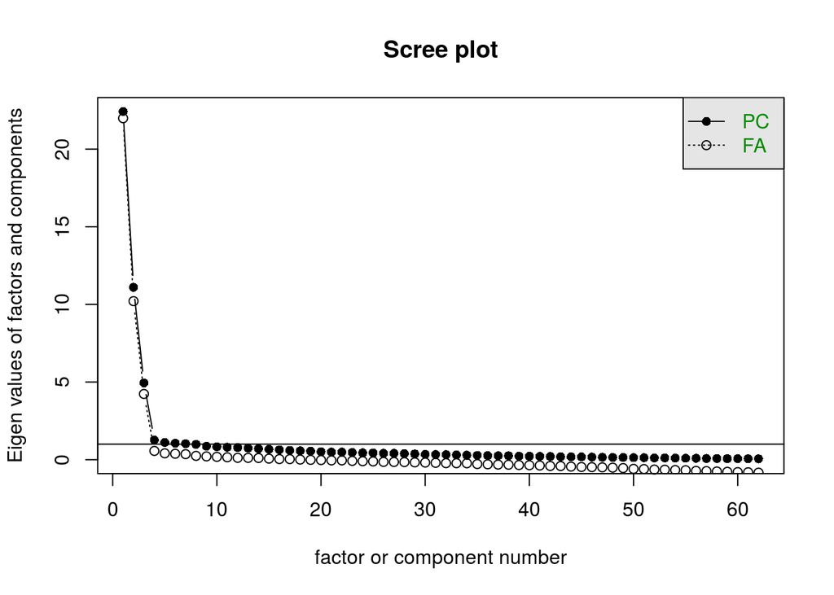

The EFA below tells a slightly different story than above, but there are a lot of cross loadings, and I don’t know whether I should trust this method entirely on this type of data. This is a really well fitting EFA, though.

```
## Factor Analysis using method =  pa
## Call: fa(r = statTypeCor, nfactors = 2, n.obs = 100, rotate = "oblimin",
##     scores = "tenBerge", fm = "pa")
## Standardized loadings (pattern matrix) based upon correlation matrix
##               item   PA1   PA2   h2   u2 com
## caring          11  0.90  0.05 0.80 0.20 1.0
## nice            40  0.90 -0.02 0.81 0.19 1.0
## helpful         28  0.89  0.05 0.78 0.22 1.0
## sympathetic     58  0.88  0.06 0.77 0.23 1.0
## comforting      12  0.88  0.11 0.76 0.24 1.0
## fair            20  0.87  0.09 0.74 0.26 1.0
## giving          26  0.86  0.01 0.73 0.27 1.0
## considerate     14  0.86  0.04 0.72 0.28 1.0
## respectful      47  0.85  0.00 0.71 0.29 1.0
## patient         42  0.84  0.00 0.70 0.30 1.0
## honest          29  0.84 -0.02 0.70 0.30 1.0
## genuine         25  0.83  0.08 0.68 0.32 1.0
## welcoming       62  0.82  0.00 0.67 0.33 1.0
## trustworthy     60  0.82 -0.05 0.68 0.32 1.0
## humble          30  0.81  0.15 0.64 0.36 1.1
## loyal           37  0.80 -0.09 0.67 0.33 1.0
## friendly        23  0.79 -0.16 0.68 0.32 1.1
## bossy            9 -0.77 -0.05 0.58 0.42 1.0
## mean            38 -0.76  0.13 0.62 0.38 1.1
## fake            21 -0.76  0.03 0.58 0.42 1.0
## selfish         51 -0.75  0.05 0.58 0.42 1.0
## snobby          54 -0.75  0.00 0.56 0.44 1.0
## calm            10  0.74 -0.05 0.56 0.44 1.0
## rude            49 -0.74  0.09 0.57 0.43 1.0
## controlling     15 -0.74 -0.03 0.54 0.46 1.0
## rule-follower   50  0.73  0.23 0.54 0.46 1.2
## agressive        3 -0.67  0.09 0.47 0.53 1.0
## studious        57  0.63  0.08 0.39 0.61 1.0
## smart           53  0.62 -0.14 0.42 0.58 1.1
## risky           48 -0.56 -0.02 0.31 0.69 1.0
## jealous         32 -0.55  0.32 0.46 0.54 1.6
## stubborn        56 -0.54  0.09 0.31 0.69 1.1
## grumpy          27 -0.51  0.37 0.45 0.55 1.8
## motivated       39  0.49 -0.29 0.36 0.64 1.6
## angry            4 -0.48  0.41 0.45 0.55 2.0
```

[output cut: 46 more lines]

```
## The root mean square of the residuals (RMSR) is  0.08
## The df corrected root mean square of the residuals is  0.08
##
## The harmonic number of observations is  100 with the empirical chi square  2437.72  with prob <  2.7e-24
## The total number of observations was  100  with MLE Chi Square =  1754.2  with prob <  0.59
##
## Tucker Lewis Index of factoring reliability =  1.005
## RMSEA index =  0.054  and the 90 % confidence intervals are  NA NA
## BIC =  -6387.74
## Fit based upon off diagonal values = 0.96
## Measures of factor score adequacy
##                                                 PA1  PA2
## Correlation of scores with factors             0.99 0.98
## Multiple R square of scores with factors       0.99 0.96
## Minimum correlation of possible factor scores  0.97 0.91
```

|  | PA1 | PA2 |
| --- | --- | --- |
| caring | 0.90 |  |
| nice | 0.90 |  |
| helpful | 0.89 |  |
| sympathetic | 0.88 |  |
| comforting | 0.88 | 0.11 |
| fair | 0.87 |  |
| giving | 0.86 |  |
| considerate | 0.86 |  |
| respectful | 0.85 |  |
| patient | 0.84 |  |
| honest | 0.84 |  |
| genuine | 0.83 |  |
| welcoming | 0.82 |  |
| trustworthy | 0.82 |  |
| humble | 0.81 | 0.15 |
| loyal | 0.80 |  |
| friendly | 0.79 | -0.16 |
| bossy | -0.77 |  |
| mean | -0.76 | 0.13 |
| fake | -0.76 |  |
| selfish | -0.75 |  |
| snobby | -0.75 |  |
| calm | 0.74 |  |
| rude | -0.74 |  |
| controlling | -0.74 |  |
| rule-follower | 0.73 | 0.23 |
| agressive | -0.67 |  |
| studious | 0.63 |  |
| smart | 0.62 | -0.14 |
| risky | -0.56 |  |
| jealous | -0.55 | 0.32 |
| stubborn | -0.54 |  |
| grumpy | -0.51 | 0.37 |
| motivated | 0.49 | -0.29 |
| angry | -0.48 | 0.41 |
| poor |  | 0.79 |
| ugly |  | 0.76 |
| loner |  | 0.76 |
| depressed |  | 0.76 |
| boring |  | 0.73 |
| lonely |  | 0.73 |
| popular |  | -0.72 |
| plain | 0.17 | 0.72 |
| awkward |  | 0.72 |
| shy | 0.21 | 0.72 |
| attractive |  | -0.69 |
| trendy |  | -0.67 |
| outgoing |  | -0.66 |
| pushover | 0.18 | 0.64 |
| cool | 0.11 | -0.62 |
| confident |  | -0.62 |
| leader | 0.11 | -0.61 |
| social | 0.12 | -0.58 |
| insecure | -0.23 | 0.58 |
| athletic |  | -0.57 |
| adventurous |  | -0.47 |
| flirty | -0.14 | -0.46 |
| admired | 0.43 | -0.45 |
| dependent | 0.27 | 0.41 |
| lazy | -0.38 | 0.39 |
| funny | 0.38 | -0.38 |
| daring | -0.29 | -0.37 |

Here’s the same sparse PCA method from before (will it match?!). Again, to be taken with a grain of salt.

```
## iterations 10
## iterations 10
## iterations 10
## iterations 10
## iterations 10
```

```
## [[1]]
##   para Nitems
##      1     49
##
## [[2]]
##   para Nitems
##   1.02  49.00
##
## [[3]]
##   para Nitems
##   1.04  49.00
##
## [[4]]
##   para Nitems
##   1.06  48.00
##
## [[5]]
##   para Nitems
##   1.08  46.00
```

|  | PC1 | PC2 |
| --- | --- | --- |
| admired |  | 0.048 |
| adventurous |  |  |
| agressive | 0.09 |  |
| angry |  | -0.067 |
| athletic |  | 0.018 |
| attractive |  | 0.063 |
| awkward |  | -0.354 |
| boring |  | -0.284 |
| bossy | 0.146 |  |
| calm | -0.016 |  |
| caring | -0.407 |  |
| comforting |  |  |
| confident |  | 0.008 |
| considerate | -0.156 |  |
| controlling | 0.088 |  |
| cool |  | 0.002 |
| daring |  |  |
| dependent |  |  |
| depressed |  | -0.313 |
| fair | -0.148 |  |
| fake | 0.23 |  |
| flirty |  |  |
| friendly | -0.159 |  |
| funny |  |  |
| genuine | -0.176 |  |
| giving | -0.216 |  |
| grumpy |  |  |
| helpful | -0.328 |  |
| honest | -0.083 |  |
| humble | -0.002 |  |
| insecure |  | -0.22 |
| jealous |  |  |
| lazy |  |  |
| leader |  | 0.215 |
| lonely |  | -0.114 |
| loner |  | -0.335 |
| loyal | -0.11 |  |
| mean | 0.286 |  |
| motivated |  |  |
| nice | -0.288 |  |
| outgoing |  | 0.23 |
| patient | -0.105 |  |
| plain |  | -0.217 |
| poor |  | -0.354 |
| popular |  | 0.259 |
| pushover |  | -0.109 |
| respectful | -0.27 |  |
| risky |  |  |
| rude | 0.208 |  |
| rule-follower | -0.007 |  |
| selfish | 0.206 |  |
| shy |  | -0.164 |
| smart |  |  |
| snobby | 0.067 |  |
| social |  | 0.087 |
| stubborn |  |  |
| studious |  |  |
| sympathetic | -0.351 |  |
| trendy |  | 0.207 |
| trustworthy | -0.041 |  |
| ugly |  | -0.288 |
| welcoming | -0.064 |  |

Another approach: Using glmnet, we can get a good set of cross-validated classifying features – in our case, adjectives.

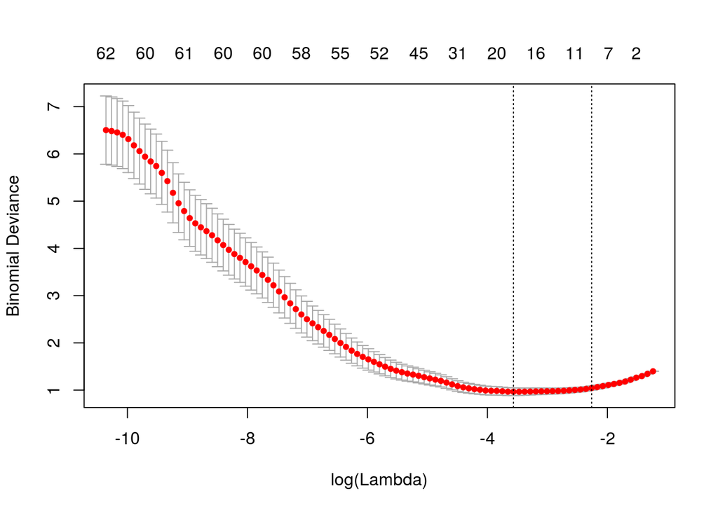

These are the items that give have the most information for classification of the type of status. These should be the items that show the biggest differences between accepted and controversial ratings. Hopefully, they all show up in our factor analyses above, too.

This table summarizes the GLMnet, machine learning, predictive items across self ratings and type ratings.

[output not shown]